# Assignment 1: PyTorch Basics

### Part B-5(v) [3pt DISCUSSION]

Why did we only use the test data set at the very end? Why is it important that we use the test data as little as possible?

```python
'''
PROVIDE YOUR ANSWER BELOW


We only used the test set at the very end because it is meant to be an unbiased and as a final evaluation
of how well our model generalizes to truly unseen data.


It’s important to use the test set as little as possible because:

1. Avoid False Success. If the teacher wants to know how well the students learn from the course,
   it would be less likely the teacher shares diretly with the students the final exam questions,
   becasue it is not really testing students' learning performance, but memorlization.
   The same idea applies to test set.

2. Avoid false confidence. If the test set leaks, the model might look perfect on paper with low test error,
   since we are tuning the model based on the test set. However, the model would fail terribly in an actual prediction task.
   This is because it learned/memorized the surface pattern of the test set instead of the underlying patterns.


3. Maintaining statistical integrity. Every time we use the test set to make a decision, we lose its ability to provide
   an unbiased estimate. However, if we use it only once at the end, this action ensures that
   our final report is statistically reasonable and is trustworthy in its reflection of the model’s quality.



'''
```

### Part B-5(vi) [3pt RESULT]

Preprocess the images from the secret test set provided below and classify these images into the 7 class labels from the garbage dataset using your chosen model. Report the model predictions by your chosen model on this test dataset as a csv file called 'labels_part_b5.csv', containing the name of the images and their corresponsing predicted labels for all the images in the folder.

```python
!pip install wget
```

```
  Preparing metadata (setup.py) ... done
```

```python
import wget
# Correct URL for raw file content on GitHub
raw_url = 'https://raw.githubusercontent.com/Sabaae/Dataset/main/secret_testset.zip'
myfile = wget.download(raw_url)
```

```python
# TO BE COMPLETED

import os
import shutil
import glob
import torch
import torch.nn.functional as F
from torchvision import transforms
from PIL import Image
import csv
from google.colab import drive

# Re-defining classes as the kernel was reset
classes = ['battery', 'biological', 'cardboard', 'glass', 'metal', 'paper', 'plastic']

# Mount Drive first to ensure we can access the saved weights
drive.mount('/content/gdrive', force_remount=True)

# Prepare model for inference and load weights
device = torch.device("cuda" if torch.cuda.is_available() else "cpu")
net = LargeNet().to(device)

# Set the correct path to the best epoch checkpoint
checkpoint_path = '/content/gdrive/MyDrive/garbage_model_runs/model_large_bs256_lr0.01_epoch22'

if os.path.exists(checkpoint_path):
    print(f"Found it. Loading weights from {checkpoint_path}")
    net.load_state_dict(torch.load(checkpoint_path, map_location=device))
    net.eval()
else:
    # If the above fails, let's list the directory to see where it is
    print(f"Still can't find the file. Current content of MyDrive:")
    !ls /content/gdrive/MyDrive/
    raise FileNotFoundError(f"Checkpoint not found at {checkpoint_path}.")

# Handle the secret test set zip file
zip_file_path = 'secret_testset.zip'
extract_base_dir = '/content/secret_testset_b5/'
os.makedirs(extract_base_dir, exist_ok=True)

print(f"Unzipping {zip_file_path} to {extract_base_dir}")
_ = !unzip -o "{zip_file_path}" -d "{extract_base_dir}"

if os.path.exists(os.path.join(extract_base_dir, '__MACOSX')):
    shutil.rmtree(os.path.join(extract_base_dir, '__MACOSX'))

# Locate the actual image folder and list files
found_image_paths = []
for root, _, files in os.walk(extract_base_dir):
    for file in files:
        if file.lower().endswith(('.jpg', '.jpeg', '.png', '.bmp')):
            found_image_paths.append(os.path.join(root, file))

if not found_image_paths:
    raise FileNotFoundError(f"No image files found in {extract_base_dir}.")

test_dir = os.path.dirname(found_image_paths[0])
image_files = sorted([os.path.basename(p) for p in found_image_paths])

# Transformations match the training phase
transform = transforms.Compose([
    transforms.Resize((128, 128)),
    transforms.ToTensor(),
    transforms.Normalize((0.5,), (0.5,))
])

predictions = []
print(f"Starting inference on {len(image_files)} secret images...")

for img_file in image_files:
    img_path = os.path.join(test_dir, img_file)
    try:
        img = Image.open(img_path).convert('RGB')
        img_tensor = transform(img).unsqueeze(0).to(device)

        with torch.no_grad():
            output = net(img_tensor)
            _, pred = torch.max(output, 1)
            predictions.append(classes[pred.item()])
    except Exception as e:
        print(f"Error processing image {img_file}: {e}")
        predictions.append('unknown')

# Save the model predictions to the required CSV format
output_csv_filename = 'labels_part_b5.csv'
with open(output_csv_filename, 'w', newline='') as f:
    writer = csv.writer(f)
    writer.writerow(['image_name', 'predicted_label'])
    for name, pred in zip(image_files, predictions):
        writer.writerow([name, pred])

print(f"\nPredictions saved to {output_csv_filename} ({len(predictions)} images)")
```

[output not shown]

## Part B-6. Fully-Connected Linear ANN vs CNN [4pt RESULT]

Test out a 3-layer linear fully-connected ANN architecture (see simpleANN below). You should explore different hyperparameter settings to determine how well you can do on the validation dataset. Once satisified with the performance, you may test it out on the test data.

Similar to what you did in the previous part, report the model predictions by your best ANN architecture on the secret test dataset as a csv file called 'labels_part_b6.csv', containing the names of the images and their corresopnding predicted labels for all the images in the folder.

How does the your best CNN model compare with an 2-layer linear ANN model (no convolutional layers) on classifying garbage dataset images?

```python
class simpleANN(nn.Module):
    def __init__(self):
        super(simpleANN, self).__init__()
        self.name = "simple"
        self.fc1 = nn.Linear(128*128*3, 256)
        self.fc2 = nn.Linear(256, 128)
        self.fc3 = nn.Linear(128, 7)

    def forward(self, x):
        x = x.view(-1, 128*128*3)
        x = F.relu(self.fc1(x))
        x = F.relu(self.fc2(x))
        x = self.fc3(x)
        return x
```

```
Training SimpleANN with default parameters (bs=64, lr=0.01)...
Using device: cuda
Epoch 1: Train err: 0.7004, Train loss: 1.7561 | Validation err: 0.6085, Validation loss: 1.5713
Epoch 2: Train err: 0.5622, Train loss: 1.5016 | Validation err: 0.5317, Validation loss: 1.4436
Epoch 3: Train err: 0.4716, Train loss: 1.2823 | Validation err: 0.5079, Validation loss: 1.3908
Epoch 4: Train err: 0.4167, Train loss: 1.1688 | Validation err: 0.5503, Validation loss: 1.4820
Epoch 5: Train err: 0.3975, Train loss: 1.1080 | Validation err: 0.5185, Validation loss: 1.4139
Epoch 6: Train err: 0.3419, Train loss: 0.9397 | Validation err: 0.4921, Validation loss: 1.4179
Epoch 7: Train err: 0.2897, Train loss: 0.8236 | Validation err: 0.4788, Validation loss: 1.4458
Epoch 8: Train err: 0.2943, Train loss: 0.8239 | Validation err: 0.5079, Validation loss: 1.6372
Epoch 9: Train err: 0.2328, Train loss: 0.7097 | Validation err: 0.5741, Validation loss: 1.6662
Epoch 10: Train err: 0.1964, Train loss: 0.5391 | Validation err: 0.4974, Validation loss: 1.7873
Epoch 11: Train err: 0.2116, Train loss: 0.6058 | Validation err: 0.5476, Validation loss: 2.1780
Epoch 12: Train err: 0.1958, Train loss: 0.5882 | Validation err: 0.5000, Validation loss: 1.7629
Epoch 13: Train err: 0.1925, Train loss: 0.5601 | Validation err: 0.5238, Validation loss: 1.8983
Epoch 14: Train err: 0.1931, Train loss: 0.5307 | Validation err: 0.4841, Validation loss: 1.8048
Epoch 15: Train err: 0.1448, Train loss: 0.4310 | Validation err: 0.4921, Validation loss: 2.0777
Epoch 16: Train err: 0.1230, Train loss: 0.3778 | Validation err: 0.4868, Validation loss: 2.1387
Epoch 17: Train err: 0.1111, Train loss: 0.3171 | Validation err: 0.5053, Validation loss: 2.2443
Epoch 18: Train err: 0.1104, Train loss: 0.3027 | Validation err: 0.5026, Validation loss: 2.1104
Epoch 19: Train err: 0.0913, Train loss: 0.2678 | Validation err: 0.5608, Validation loss: 2.8146
Epoch 20: Train err: 0.1045, Train loss: 0.2937 | Validation err: 0.5106, Validation loss: 2.4700
Epoch 21: Train err: 0.0919, Train loss: 0.2518 | Validation err: 0.5503, Validation loss: 2.5985
Epoch 22: Train err: 0.1005, Train loss: 0.2821 | Validation err: 0.4735, Validation loss: 2.5306
Epoch 23: Train err: 0.1045, Train loss: 0.3131 | Validation err: 0.5026, Validation loss: 2.6305
Epoch 24: Train err: 0.0747, Train loss: 0.2304 | Validation err: 0.4868, Validation loss: 2.6524
Epoch 25: Train err: 0.0569, Train loss: 0.1762 | Validation err: 0.5026, Validation loss: 2.7395
Epoch 26: Train err: 0.0602, Train loss: 0.1690 | Validation err: 0.4841, Validation loss: 2.6366
Epoch 27: Train err: 0.0642, Train loss: 0.1908 | Validation err: 0.5132, Validation loss: 3.1812
Epoch 28: Train err: 0.0761, Train loss: 0.2401 | Validation err: 0.5053, Validation loss: 2.8811
Epoch 29: Train err: 0.0761, Train loss: 0.2186 | Validation err: 0.5079, Validation loss: 3.1008
Epoch 30: Train err: 0.0866, Train loss: 0.2591 | Validation err: 0.4868, Validation loss: 2.7322
Finished Training
Total time elapsed: 379.82 seconds

SimpleANN Training Curves:
```

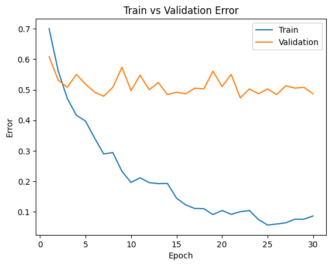

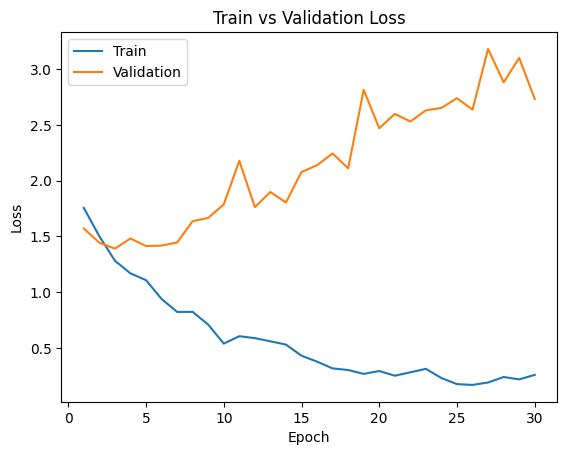

```python
# TO BE COMPLETED

# Mount Google Drive
from google.colab import drive
drive.mount('/content/drive')

# Set save directory
import os
save_dir = "/content/drive/MyDrive/garbage_model_runs"
os.makedirs(save_dir, exist_ok=True)

# Train SimpleANN with default parameters

print("Training SimpleANN with default parameters (bs=64, lr=0.01)...")
simple_net = simpleANN()
train_net(simple_net, batch_size=64, learning_rate=0.01, num_epochs=30)

# Plot training curves

print("\nSimpleANN Training Curves:")
model_path = get_model_name("simple", batch_size=64, learning_rate=0.01, epoch=29)
model_path = os.path.join(save_dir, model_path)
plot_training_curve(model_path)
```

```python
# TO BE COMPLETED



import pandas as pd

# 1) Train all hyperparameter combinations
learning_rates = [0.001, 0.01, 0.1]
batch_sizes = [16, 64, 256, 512]
results = []

for lr in learning_rates:
    for bs in batch_sizes:
        print(f"\nTraining: bs={bs}, lr={lr}")

        simple_net = simpleANN()
        train_net(simple_net, batch_size=bs, learning_rate=lr, num_epochs=30)

        device = torch.device("cuda" if torch.cuda.is_available() else "cpu")
        simple_net = simple_net.to(device)
        criterion = nn.CrossEntropyLoss()

        _, val_loader, _, _ = get_data_loader(data_dir='/content/garbage_dataset', batch_size=bs)
        val_err, val_loss = evaluate(simple_net, val_loader, criterion)

        results.append({'Batch Size': bs, 'Learning Rate': lr, 'Val Error': val_err})
        print(f"Val Error: {val_err:.4f}")


# 2) Print the Top 5 configurations

df = pd.DataFrame(results)
df_top5 = df.sort_values('Val Error').head(5)
print("\nTop 5 Configurations:")
print(df_top5.to_string(index=False))
```

```
Training: bs=16, lr=0.001
Using device: cuda
Epoch 1: Train err: 0.6911, Train loss: 1.7245 | Validation err: 0.6005, Validation loss: 1.5299
Epoch 2: Train err: 0.5529, Train loss: 1.4434 | Validation err: 0.5397, Validation loss: 1.4219
Epoch 3: Train err: 0.4808, Train loss: 1.3055 | Validation err: 0.5370, Validation loss: 1.4263
Epoch 4: Train err: 0.4239, Train loss: 1.1790 | Validation err: 0.4735, Validation loss: 1.3445
Epoch 5: Train err: 0.3896, Train loss: 1.1031 | Validation err: 0.4868, Validation loss: 1.3503
Epoch 6: Train err: 0.3571, Train loss: 1.0028 | Validation err: 0.4841, Validation loss: 1.3534
Epoch 7: Train err: 0.2877, Train loss: 0.8714 | Validation err: 0.5053, Validation loss: 1.3833
Epoch 8: Train err: 0.2745, Train loss: 0.8101 | Validation err: 0.5132, Validation loss: 1.4259
Epoch 9: Train err: 0.2513, Train loss: 0.7299 | Validation err: 0.5476, Validation loss: 1.6288
Epoch 10: Train err: 0.2116, Train loss: 0.6416 | Validation err: 0.4868, Validation loss: 1.4343
Epoch 11: Train err: 0.1885, Train loss: 0.5746 | Validation err: 0.5344, Validation loss: 1.6157
Epoch 12: Train err: 0.1561, Train loss: 0.5004 | Validation err: 0.5132, Validation loss: 1.5839
Epoch 13: Train err: 0.1415, Train loss: 0.4489 | Validation err: 0.5053, Validation loss: 1.6090
Epoch 14: Train err: 0.1243, Train loss: 0.4020 | Validation err: 0.5053, Validation loss: 1.6755
Epoch 15: Train err: 0.0999, Train loss: 0.3499 | Validation err: 0.4868, Validation loss: 1.6228
Epoch 16: Train err: 0.0873, Train loss: 0.3094 | Validation err: 0.4868, Validation loss: 1.7366
Epoch 17: Train err: 0.0939, Train loss: 0.2992 | Validation err: 0.5053, Validation loss: 1.7852
Epoch 18: Train err: 0.0675, Train loss: 0.2390 | Validation err: 0.5026, Validation loss: 1.8648
Epoch 19: Train err: 0.0575, Train loss: 0.2035 | Validation err: 0.5053, Validation loss: 1.9747
Epoch 20: Train err: 0.0860, Train loss: 0.2739 | Validation err: 0.5317, Validation loss: 2.0838
Epoch 21: Train err: 0.0608, Train loss: 0.2132 | Validation err: 0.4947, Validation loss: 1.9246
Epoch 22: Train err: 0.0278, Train loss: 0.1284 | Validation err: 0.4894, Validation loss: 2.2323
Epoch 23: Train err: 0.0397, Train loss: 0.1388 | Validation err: 0.4735, Validation loss: 2.0035
Epoch 24: Train err: 0.0265, Train loss: 0.1091 | Validation err: 0.5132, Validation loss: 2.1767
Epoch 25: Train err: 0.0324, Train loss: 0.1189 | Validation err: 0.5106, Validation loss: 2.1017
Epoch 26: Train err: 0.0132, Train loss: 0.0731 | Validation err: 0.4947, Validation loss: 2.1315
Epoch 27: Train err: 0.0159, Train loss: 0.0673 | Validation err: 0.5185, Validation loss: 2.3551
Epoch 28: Train err: 0.0205, Train loss: 0.0698 | Validation err: 0.4947, Validation loss: 2.2659
Epoch 29: Train err: 0.0099, Train loss: 0.0494 | Validation err: 0.5159, Validation loss: 2.4957
Epoch 30: Train err: 0.0066, Train loss: 0.0401 | Validation err: 0.5026, Validation loss: 2.3479
Finished Training
Total time elapsed: 259.55 seconds
Val Error: 0.1455

Training: bs=64, lr=0.001
Using device: cuda
Epoch 1: Train err: 0.7381, Train loss: 1.8748 | Validation err: 0.6481, Validation loss: 1.7644
Epoch 2: Train err: 0.6343, Train loss: 1.7015 | Validation err: 0.6376, Validation loss: 1.6310
```

[output cut: 384 more lines]

```
Epoch 27: Train err: 0.8254, Train loss: 1.9524 | Validation err: 0.8360, Validation loss: 1.9384
Epoch 28: Train err: 0.8267, Train loss: 1.9074 | Validation err: 0.8333, Validation loss: 1.9393
Epoch 29: Train err: 0.8386, Train loss: 1.9141 | Validation err: 0.8413, Validation loss: 1.9383
Epoch 30: Train err: 0.8274, Train loss: 1.9100 | Validation err: 0.8360, Validation loss: 1.9928
Finished Training
Total time elapsed: 258.39 seconds
Val Error: 0.8360

Top 5 Configurations:
 Batch Size  Learning Rate  Val Error
         16          0.001   0.145503
        256          0.010   0.150794
         64          0.010   0.158730
         64          0.001   0.185185
        512          0.010   0.216931
```